# Mo_Wentao_hw5

Due **March 7 (Monday), 2022** by 11:59pm. Submit by editing this file and then uploading to Canvas.

Please rename this file with **"LastName_FirstName_hw5"**

The purpose of this assignment is to practice accessing and analyzing data in a database.

Notes:

1. Put your answers in new cells after each exercise. You can make as many new cells as you like. Use code cells for code and Markdown cells for text. Answer all questions with complete sentences.
2. Your code should be readable; writing a piece of code should be compared to writing a page of a book. Adopt the **one-statement-per-line** rule. The lenghth of your code should not exceed the maximum length of each cell for display. If your code is too long, you should split it into multiple lines to improve readability. (You will lose one point for each line that does not follow the rule.)
3. To help understand and maintain code, you should always add comments to explain your code. Use the hash symbol (#) to start writing a comment (homework without any comments will automatically receive 0 points). If you are writing a function, consider using *docstring* to add explanation.
4. Submit your final work with a **.pdf** (or a **.html**) file to Canvas. To convert a .ipynb file to a .pdf/.html file, go to "File", click "Download as", and then click "PDF via LaTeX"/"HTML".
5. Please do not clear your output so that we can see your answers without running all of the cells.

**For full credit, do most of your work in SQL.** Subsetting, sorting, grouping, aggregation, and merging can all be done in SQL. It is okay to use Python code for parts of your analysis that are difficult or impossible to do in SQL, such as creating visualizations or computing statistics (other than the mean).

## Lahman's Baseball Database

In this assignment, you'll use SQL queries and **pandas** to explore data in [Lahman's Baseball Database](http://www.seanlahman.com/baseball-archive/statistics/), which contains "complete batting and pitching statistics from 1871 to 2020, plus fielding statistics, standings, team stats, managerial records, post-season data, and more."

We use the 2019 version for this homework. You can find the database in SQLite format in the hw5 folder on Piazza.

Documentation for the database, including a description of all tables, is in the `readme2019.txt` file included in the hw5 folder.

**Exercises:**

1. (3 points) From 2006 to 2016, which 5 teams had the highest payrolls? Payroll means the sum of the salaries for all people on the team in a given year.
2. (3 points) Is there any general trend in payrolls over this time period? (Hint: make a plot to find the trend)
3. (2 points) There are at least 2 anomalies in the payrolls over this time period. What are they, and can you find information (online or elsewhere) to explain them?
4. (2 points) How do the top 5 teams compare to other teams?

```python
# From 2006 to 2016, determine which 5 teams had the highest payrolls, where payroll means the sum of the salaries for all people on the
# team in a given year.

import numpy as np # First, we import all the required packages.
import pandas as pd # First, we import all the required packages.

import sqlite3 as sql # First, we import all the required packages.

db = sql.connect("lahmansbaseballdb.sqlite") # First, we apply the sql package to connect
```

```python
# we can first check to display the database.
db
```

```
<sqlite3.Connection at 0x1c80df64300>
```

```python
cur = db.execute("SELECT * FROM sqlite_master")
# SQLite databases store metadata in a special table called sqlite_master.
# We can use sqlite_master to find out the names of the other tables in the database.
```

```python
cur = db.execute("SELECT * FROM sqlite_master")  #Using the execute function
rows = cur.fetchall() # To gain access to the rows names from the sql database. #15210 #15939
```

```python
pd.read_sql("SELECT * FROM sqlite_master", db).head() # We can gain access to the sql database.
```

|  | type | name | tbl_name | rootpage | sql |
| --- | --- | --- | --- | --- | --- |
| 0 | table | allstarfull | allstarfull | 2 | CREATE TABLE "allstarfull" (\n\t"ID" INTEGER N... |
| 1 | index | allstarfull_lgID | allstarfull | 3 | CREATE INDEX "allstarfull_lgID" ON "allstarful... |
| 2 | index | allstarfull_playerID | allstarfull | 4 | CREATE UNIQUE INDEX "allstarfull_playerID" ON ... |
| 3 | index | allstarfull_team_ID | allstarfull | 5 | CREATE INDEX "allstarfull_team_ID" ON "allstar... |
| 4 | table | appearances | appearances | 151 | CREATE TABLE "appearances" (\n\t"ID" INTEGER N... |

```python
pd.read_sql("SELECT Name, Type FROM sqlite_master", db).head() # We can only read only name, and type from the spl database.
```

|  | name | type |
| --- | --- | --- |
| 0 | allstarfull | table |
| 1 | allstarfull_lgID | index |
| 2 | allstarfull_playerID | index |
| 3 | allstarfull_team_ID | index |
| 4 | appearances | table |

```python
pd.read_sql("SELECT * FROM salaries;", db).head() # Then, we select the corresponding table ("Salaries")
```

|  | ID | yearID | teamID | team_ID | lgID | playerID | salary |
| --- | --- | --- | --- | --- | --- | --- | --- |
| 0 | 1 | 1985 | ATL | 1918 | NL | barkele01 | 870000.0 |
| 1 | 2 | 1985 | ATL | 1918 | NL | bedrost01 | 550000.0 |
| 2 | 3 | 1985 | ATL | 1918 | NL | benedbr01 | 545000.0 |
| 3 | 4 | 1985 | ATL | 1918 | NL | campri01 | 633333.0 |
| 4 | 5 | 1985 | ATL | 1918 | NL | ceronri01 | 625000.0 |

```python
pd.read_sql("SELECT * FROM salaries WHERE yearID BETWEEN 2006 AND 2016;", db).head() # We then select the accurate corresponding time period.
```

|  | ID | yearID | teamID | team_ID | lgID | playerID | salary |
| --- | --- | --- | --- | --- | --- | --- | --- |
| 0 | 17295 | 2006 | ARI | 2506 | NL | aquingr01 | 342000.0 |
| 1 | 17296 | 2006 | ARI | 2506 | NL | batismi01 | 4750000.0 |
| 2 | 17297 | 2006 | ARI | 2506 | NL | byrneer01 | 2250000.0 |
| 3 | 17298 | 2006 | ARI | 2506 | NL | clarkto02 | 1034000.0 |
| 4 | 17299 | 2006 | ARI | 2506 | NL | counscr01 | 1750000.0 |

## Important, we have to group by our column in order to calculate the sum for all playeres in one team

```python
# For the first line here, we select the sum of the salary and their corresponding teamID, and year ID from the Salaries database
# For the second line here, we specify the condition: Let the year Between 2006 and 2016.
# For the third line here, we then group by the yearID, and teamID.
# For the fourth line here, we order our result from the largest payroll to the smallest payroll.

import pandas as pd # Import the required package
pd.read_sql("""
SELECT SUM(salary)AS sum , teamID, yearID FROM salaries
WHERE yearID BETWEEN 2006 AND 2016
GROUP BY yearID, teamID
ORDER BY SUM(salary) DESC
""", db).head(20)
```

|  | sum | teamID | yearID |
| --- | --- | --- | --- |
| 0 | 231978886.0 | NYA | 2013 |
| 1 | 223362196.0 | LAN | 2013 |
| 2 | 222997792.0 | NYA | 2016 |
| 3 | 221288380.0 | LAN | 2016 |
| 4 | 217014600.0 | LAN | 2014 |
| 5 | 215792000.0 | LAN | 2015 |
| 6 | 212751957.0 | NYA | 2015 |
| 7 | 207896789.0 | NYA | 2008 |
| 8 | 206333389.0 | NYA | 2010 |
| 9 | 202275028.0 | NYA | 2011 |
| 10 | 201449189.0 | NYA | 2009 |
| 11 | 197543907.0 | NYA | 2014 |
| 12 | 196522289.0 | NYA | 2012 |
| 13 | 194876481.0 | DET | 2016 |
| 14 | 194663079.0 | NYA | 2006 |
| 15 | 189259045.0 | NYA | 2007 |
| 16 | 188545761.0 | BOS | 2016 |
| 17 | 181103400.0 | BOS | 2015 |
| 18 | 180944967.0 | PHI | 2014 |
| 19 | 176038723.0 | TEX | 2016 |

```python
pd.read_sql("SELECT *  FROM teams WHERE teamID = 'NYA';", db).head() # Then, we select the corresponding table ("Salaries")
# We check the name of the teamID.
```

|  | ID | yearID | lgID | teamID | franchID | divID | div_ID | teamRank | G | Ghome | ... | DP | FP | name | park | attendance | BPF | PPF | teamIDBR | teamIDlahman45 | teamIDretro |
| --- | --- | --- | --- | --- | --- | --- | --- | --- | --- | --- | --- | --- | --- | --- | --- | --- | --- | --- | --- | --- | --- |
| 0 | 425 | 1903 | AL | NYA | NYY | None | NaN | 4 | 136 | 67 | ... | 87 | 0.953 | New York Highlanders | Hilltop Park | 211808 | 106 | 105 | NYY | NYA | NYA |
| 1 | 441 | 1904 | AL | NYA | NYY | None | NaN | 2 | 155 | 75 | ... | 90 | 0.958 | New York Highlanders | Hilltop Park | 438919 | 105 | 104 | NYY | NYA | NYA |
| 2 | 457 | 1905 | AL | NYA | NYY | None | NaN | 6 | 152 | 75 | ... | 88 | 0.952 | New York Highlanders | Hilltop Park | 309100 | 111 | 110 | NYY | NYA | NYA |
| 3 | 473 | 1906 | AL | NYA | NYY | None | NaN | 2 | 155 | 76 | ... | 69 | 0.957 | New York Highlanders | Hilltop Park | 434700 | 110 | 110 | NYY | NYA | NYA |
| 4 | 489 | 1907 | AL | NYA | NYY | None | NaN | 5 | 152 | 75 | ... | 79 | 0.947 | New York Highlanders | Hilltop Park | 350020 | 108 | 110 | NYY | NYA | NYA |

5 rows × 50 columns

```python
pd.read_sql("SELECT *  FROM teams WHERE teamID = 'PHI';", db).head() # Then, we select the corresponding table ("Salaries")
# We check the name of the teamID.
```

|  | ID | yearID | lgID | teamID | franchID | divID | div_ID | teamRank | G | Ghome | ... | DP | FP | name | park | attendance | BPF | PPF | teamIDBR | teamIDlahman45 | teamIDretro |
| --- | --- | --- | --- | --- | --- | --- | --- | --- | --- | --- | --- | --- | --- | --- | --- | --- | --- | --- | --- | --- | --- |
| 0 | 121 | 1883 | NL | PHI | PHI | None | NaN | 8 | 99 | NaN | ... | 62 | 0.858 | Philadelphia Quakers | Recreation Park | NaN | 91 | 98 | PHI | PHI | PHI |
| 1 | 146 | 1884 | NL | PHI | PHI | None | NaN | 6 | 113 | NaN | ... | 67 | 0.888 | Philadelphia Quakers | Recreation Park | NaN | 94 | 99 | PHI | PHI | PHI |
| 2 | 169 | 1885 | NL | PHI | PHI | None | NaN | 3 | 111 | NaN | ... | 66 | 0.905 | Philadelphia Quakers | Recreation Park | NaN | 97 | 98 | PHI | PHI | PHI |
| 3 | 185 | 1886 | NL | PHI | PHI | None | NaN | 4 | 119 | NaN | ... | 46 | 0.921 | Philadelphia Quakers | Recreation Park | NaN | 100 | 99 | PHI | PHI | PHI |
| 4 | 202 | 1887 | NL | PHI | PHI | None | NaN | 2 | 128 | NaN | ... | 76 | 0.912 | Philadelphia Quakers | Philadelphia Baseball Grounds | NaN | 106 | 104 | PHI | PHI | PHI |

5 rows × 50 columns

## Fourth Highest payroll: Los Angeles Dodgers in 2016

## Fifth Highest payroll: Los Angeles Dodgers in 2014

# Five teams which receive higher payroll (Excluding the same team)

## 1st: NYA ; 2nd: LAN ; 3rd: DET; 4th: BOS ; 5th: PHI

# Notice! We can try another type of output: We can also apply the sql package to output the highest payroll for all ten years( which is to say, from 2006 to 2016, excluding the situation if we have different years.)

```python
# For the first line here, we select the sum of the salary and their corresponding teamID, and year ID from the Salaries database
# For the second line here, we specify the condition: Let the year Between 2006 and 2016.
# For the third line here, we then group by the just the teamID.
# For the fourth line here, we order our result from the largest payroll to the smallest payroll.

import pandas as pd # Import the required package
pd.read_sql("""
SELECT SUM(salary)AS sum , teamID, yearID FROM salaries
WHERE yearID BETWEEN 2006 AND 2016
GROUP BY teamID
ORDER BY SUM(salary) DESC
""", db)
# This time, we cam show the entire output.
```

|  | sum | teamID | yearID |
| --- | --- | --- | --- |
| 0 | 2.263671e+09 | NYA | 2006 |
| 1 | 1.675458e+09 | BOS | 2006 |
| 2 | 1.598053e+09 | LAN | 2006 |
| 3 | 1.457055e+09 | DET | 2006 |
| 4 | 1.399510e+09 | PHI | 2006 |
| 5 | 1.347061e+09 | LAA | 2006 |
| 6 | 1.315003e+09 | SFN | 2006 |
| 7 | 1.243140e+09 | CHN | 2006 |
| 8 | 1.215769e+09 | NYN | 2006 |
| 9 | 1.186187e+09 | CHA | 2006 |
| 10 | 1.151854e+09 | SLN | 2006 |
| 11 | 1.090018e+09 | SEA | 2006 |
| 12 | 1.085058e+09 | TEX | 2006 |
| 13 | 1.019353e+09 | TOR | 2006 |
| 14 | 1.009046e+09 | BAL | 2006 |
| 15 | 9.640186e+08 | WAS | 2006 |
| 16 | 9.565559e+08 | ATL | 2006 |
| 17 | 9.308869e+08 | MIN | 2006 |
| 18 | 9.236573e+08 | CIN | 2006 |
| 19 | 9.017237e+08 | MIL | 2006 |
| 20 | 8.677214e+08 | COL | 2006 |
| 21 | 8.122377e+08 | HOU | 2006 |
| 22 | 8.094887e+08 | KCA | 2006 |
| 23 | 7.865642e+08 | CLE | 2006 |
| 24 | 7.764995e+08 | ARI | 2006 |
| 25 | 7.450685e+08 | SDN | 2006 |
| 26 | 7.270517e+08 | OAK | 2006 |
| 27 | 6.724917e+08 | PIT | 2006 |
| 28 | 5.905886e+08 | TBA | 2006 |
| 29 | 3.388875e+08 | MIA | 2012 |
| 30 | 2.177977e+08 | FLO | 2006 |

# In this view of output, we are actually showing that the total payroll in total 10 years(from 2006 - 2016):

# 1st: NYA, 2nd: BOS, 3rd: LAN, 4th: DET, 5th: PHI

# Second Question: Is there any general trend in payrolls over this time period? (Hint: make a plot to find the trend)

```python
# For the first line here, we select the sum of the salary and their corresponding teamID, and year ID from the Salaries database
# For the second line here, we specify the condition: Let the year Between 2006 and 2016, and team id = "NYA"
# For the third line here, we then group by the yearID, and teamID.
# For the fourth line here, we order our result from the largest payroll to the smallest payroll.



plot_HYA = pd.read_sql("""
SELECT SUM(salary)AS sum , teamID, yearID FROM salaries
WHERE yearID >= 2006 AND teamID = 'NYA'
GROUP BY yearID, teamID
""", db)
plot_HYA
```

|  | sum | teamID | yearID |
| --- | --- | --- | --- |
| 0 | 194663079.0 | NYA | 2006 |
| 1 | 189259045.0 | NYA | 2007 |
| 2 | 207896789.0 | NYA | 2008 |
| 3 | 201449189.0 | NYA | 2009 |
| 4 | 206333389.0 | NYA | 2010 |
| 5 | 202275028.0 | NYA | 2011 |
| 6 | 196522289.0 | NYA | 2012 |
| 7 | 231978886.0 | NYA | 2013 |
| 8 | 197543907.0 | NYA | 2014 |
| 9 | 212751957.0 | NYA | 2015 |
| 10 | 222997792.0 | NYA | 2016 |

```
<function matplotlib.pyplot.show(close=None, block=None)>
```

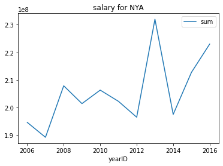

```python
import pandas as pd
import matplotlib.pyplot as plt

plot_HYA.plot(x = 'yearID', y = "sum", kind = "line", title = "salary for NYA")
plt.show
```

```python
# For the first line here, we select the sum of the salary and their corresponding teamID, and year ID from the Salaries database
# For the second line here, we specify the condition: Let the year Between 2006 and 2016, and team id = "LAN"
# For the third line here, we then group by the yearID, and teamID.
# For the fourth line here, we order our result from the largest payroll to the smallest payroll.


plot_LAN = pd.read_sql("""
SELECT SUM(salary)AS sum , teamID, yearID FROM salaries
WHERE yearID >= 2006 AND teamID = 'LAN'
GROUP BY yearID, teamID
""", db)
plot_LAN
```

|  | sum | teamID | yearID |
| --- | --- | --- | --- |
| 0 | 98447187.0 | LAN | 2006 |
| 1 | 108454524.0 | LAN | 2007 |
| 2 | 118588536.0 | LAN | 2008 |
| 3 | 100414592.0 | LAN | 2009 |
| 4 | 95358016.0 | LAN | 2010 |
| 5 | 104188999.0 | LAN | 2011 |
| 6 | 95143575.0 | LAN | 2012 |
| 7 | 223362196.0 | LAN | 2013 |
| 8 | 217014600.0 | LAN | 2014 |
| 9 | 215792000.0 | LAN | 2015 |
| 10 | 221288380.0 | LAN | 2016 |

```
<function matplotlib.pyplot.show(close=None, block=None)>
```

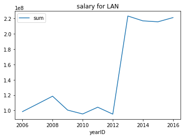

```python
import pandas as pd
import matplotlib.pyplot as plt

plot_LAN.plot(x = 'yearID', y = "sum", kind = "line", title = "salary for LAN")
plt.show
```

## In order to see more trend, we can plot two more teams that receive higher payroll.

```python
# For the first line here, we select the sum of the salary and their corresponding teamID, and year ID from the Salaries database
# For the second line here, we specify the condition: Let the year Between 2006 and 2016, and team id = "DET"
# For the third line here, we then group by the yearID, and teamID.
# For the fourth line here, we order our result from the largest payroll to the smallest payroll.


plot_DET = pd.read_sql("""
SELECT SUM(salary)AS sum , teamID, yearID FROM salaries
WHERE yearID >= 2006 AND teamID = 'DET'
GROUP BY yearID, teamID
""", db)
plot_DET
```

|  | sum | teamID | yearID |
| --- | --- | --- | --- |
| 0 | 82612866.0 | DET | 2006 |
| 1 | 94800369.0 | DET | 2007 |
| 2 | 137685196.0 | DET | 2008 |
| 3 | 115085145.0 | DET | 2009 |
| 4 | 122864928.0 | DET | 2010 |
| 5 | 105700231.0 | DET | 2011 |
| 6 | 132300000.0 | DET | 2012 |
| 7 | 145989500.0 | DET | 2013 |
| 8 | 152855500.0 | DET | 2014 |
| 9 | 172284750.0 | DET | 2015 |
| 10 | 194876481.0 | DET | 2016 |

```
<function matplotlib.pyplot.show(close=None, block=None)>
```

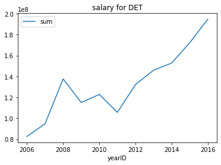

```python
import pandas as pd
import matplotlib.pyplot as plt

plot_DET.plot(x = 'yearID', y = "sum", kind = "line", title = "salary for DET") # We plot the payroll for DET from 2006 to 2016.
plt.show
```

```python
# For the first line here, we select the sum of the salary and their corresponding teamID, and year ID from the Salaries database
# For the second line here, we specify the condition: Let the year Between 2006 and 2016, and team id = "BOS"
# For the third line here, we then group by the yearID, and teamID.
# For the fourth line here, we order our result from the largest payroll to the smallest payroll.


plot_BOS = pd.read_sql("""
SELECT SUM(salary)AS sum , teamID, yearID FROM salaries
WHERE yearID >= 2006 AND teamID = 'BOS'
GROUP BY yearID, teamID
""", db)
plot_BOS
```

|  | sum | teamID | yearID |
| --- | --- | --- | --- |
| 0 | 120099824.0 | BOS | 2006 |
| 1 | 143026214.0 | BOS | 2007 |
| 2 | 133390035.0 | BOS | 2008 |
| 3 | 121345999.0 | BOS | 2009 |
| 4 | 162447333.0 | BOS | 2010 |
| 5 | 161762475.0 | BOS | 2011 |
| 6 | 173186617.0 | BOS | 2012 |
| 7 | 151530000.0 | BOS | 2013 |
| 8 | 139019929.0 | BOS | 2014 |
| 9 | 181103400.0 | BOS | 2015 |
| 10 | 188545761.0 | BOS | 2016 |

```
<function matplotlib.pyplot.show(close=None, block=None)>
```

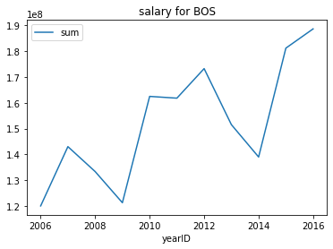

```python
import pandas as pd
import matplotlib.pyplot as plt

plot_BOS.plot(x = 'yearID', y = "sum", kind = "line", title = "salary for BOS") # We plot the payroll for BOS from 2006 to 2016.
plt.show
```

```python
# For the first line here, we select the sum of the salary and their corresponding teamID, and year ID from the Salaries database
# For the second line here, we specify the condition: Let the year Between 2006 and 2016, and team id = "DET"
# For the third line here, we then group by the yearID, and teamID.
# For the fourth line here, we order our result from the largest payroll to the smallest payroll.


plot_PHI = pd.read_sql("""
SELECT SUM(salary)AS sum , teamID, yearID FROM salaries
WHERE yearID >= 2006 AND teamID = 'PHI'
GROUP BY yearID, teamID
""", db)
plot_PHI
```

|  | sum | teamID | yearID |
| --- | --- | --- | --- |
| 0 | 88273333.0 | PHI | 2006 |
| 1 | 89428213.0 | PHI | 2007 |
| 2 | 97879880.0 | PHI | 2008 |
| 3 | 113004046.0 | PHI | 2009 |
| 4 | 141928379.0 | PHI | 2010 |
| 5 | 172976379.0 | PHI | 2011 |
| 6 | 174538938.0 | PHI | 2012 |
| 7 | 169863189.0 | PHI | 2013 |
| 8 | 180944967.0 | PHI | 2014 |
| 9 | 111693000.0 | PHI | 2015 |
| 10 | 58980000.0 | PHI | 2016 |

```
<function matplotlib.pyplot.show(close=None, block=None)>
```

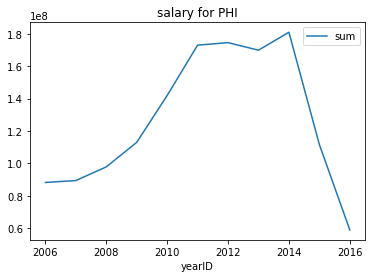

```python
import pandas as pd
import matplotlib.pyplot as plt

plot_PHI.plot(x = 'yearID', y = "sum", kind = "line", title = "salary for PHI") # We plot the payroll for PHI from 2006 to 2016.
plt.show
```